# IS 607 Project 2

Derek G. Nokes

Saturday, March 14, 2015

```r
# load the libraries
library('ggplot2')
library('ggthemes')
library('RColorBrewer')
library('Hmisc')
```

## Load Data

We begin by loading the data.

```r
# load the data
inputFile<-"C:/Users/dgn2/Documents/R/IS607/Project_2/project2_data.csv"
# load data
data <- read.csv(inputFile, header=TRUE)
```

The data is displayed in the following table:

X and Y by Quarter

| I X | I Y | II X | II Y | III X | III Y | IV X | IV Y |
| --- | --- | --- | --- | --- | --- | --- | --- |
| 10 | 8.04 | 10 | 9.14 | 10 | 7.46 | 8 | 6.58 |
| 8 | 6.95 | 8 | 8.14 | 8 | 6.77 | 8 | 5.76 |
| 13 | 7.58 | 13 | 8.74 | 13 | 12.74 | 8 | 7.71 |
| 9 | 8.81 | 9 | 8.77 | 9 | 7.11 | 8 | 8.84 |
| 11 | 8.33 | 11 | 9.26 | 11 | 7.81 | 8 | 8.47 |
| 14 | 9.96 | 14 | 8.10 | 14 | 8.84 | 8 | 7.04 |
| 6 | 7.24 | 6 | 6.13 | 6 | 6.08 | 8 | 5.25 |
| 4 | 4.26 | 4 | 3.10 | 4 | 5.39 | 19 | 12.50 |
| 12 | 10.84 | 12 | 9.13 | 12 | 8.15 | 8 | 5.56 |
| 7 | 4.82 | 7 | 7.26 | 7 | 6.42 | 8 | 7.91 |
| 5 | 5.68 | 5 | 4.74 | 5 | 5.73 | 8 | 6.89 |

## Exploratory Data Analysis

### Data Description

Once the data is loaded, we take a quick look at the attributes of the data:

```r
str(data)
```

```
## 'data.frame':    44 obs. of  3 variables:
##  $ quarter: Factor w/ 4 levels "I","II","III",..: 1 1 1 1 1 1 1 1 1 1 ...
##  $ x      : int  10 8 13 9 11 14 6 4 12 7 ...
##  $ y      : num  8.04 6.95 7.58 8.81 8.33 ...
```

We can see that there are 44 rows and 3 columns in our data set (i.e., $quarter$, $x$, and $y$).

Data Description

| variable | description |
| --- | --- |
| quarter | is a factor with 4 levels (I, II, III, & IV) |
| x | is an int |
| y | is a decimal number |

A quick summary of the data by the $quarter$ factor does not provide much insight.

```r
# create the data summary
summaries <- aggregate(data$y, by=list(data$quarter),FUN=summary)
# relabel the data summary
colnames(summaries)<-c('Group','')
summaries
```

```
##   Group  .Min. .1st Qu. .Median  .Mean .3rd Qu.  .Max.
## 1     I  4.260    6.315   7.580  7.501    8.570 10.840
## 2    II  3.100    6.695   8.140  7.501    8.950  9.260
## 3   III  5.390    6.250   7.110  7.500    7.980 12.740
## 4    IV  5.250    6.170   7.040  7.501    8.190 12.500
```

### Graphical Exploration

First, we create a single scatter plot varying the color by quarter.

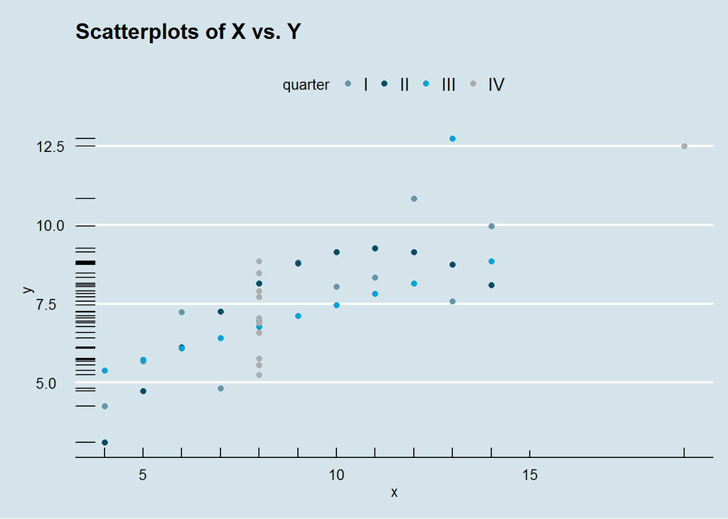

```r
# graph the data
p <- ggplot(data, aes(x, y))+theme_economist() +
  scale_colour_economist() + ggtitle("Scatterplots of X vs. Y") +
  geom_rug()
p + geom_point(aes(colour = quarter))
```

The patterns associated with each quarter are difficult to see on a single scatter plot, so we split out the quarters into separate scatter plots.

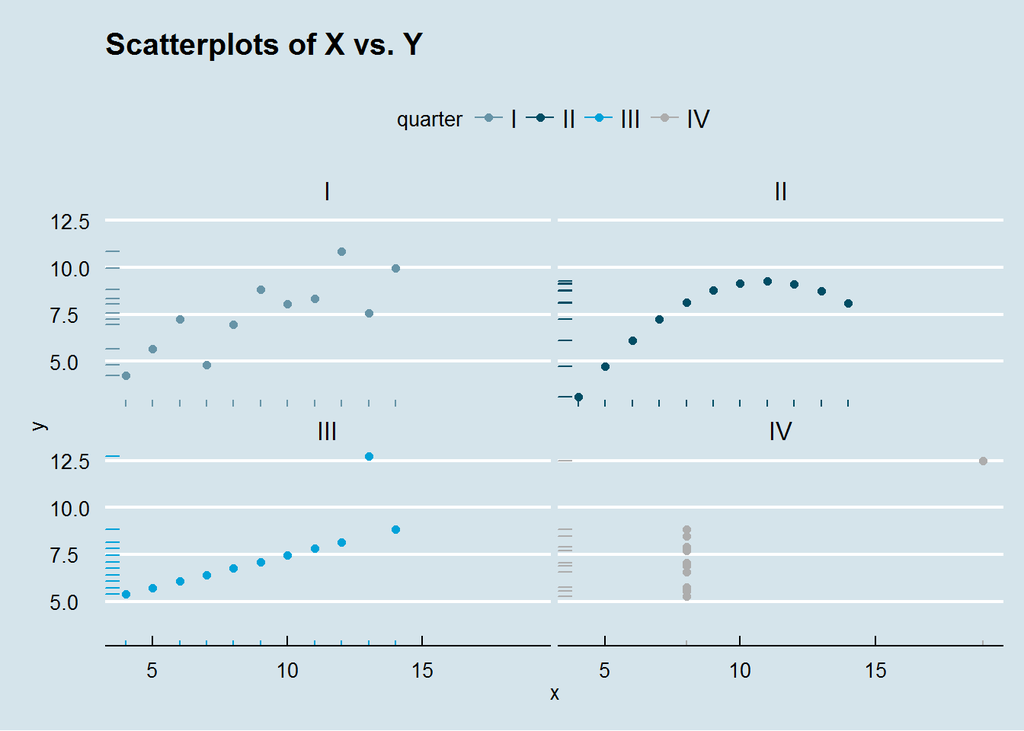

```r
qplot(x,y, data=data,color=quarter,facets=~quarter,
      xlab="x", ylab="y",main="Scatterplots of X vs. Y") +
  geom_rug() + scale_fill_brewer() +
  theme_economist() + scale_colour_economist()
```

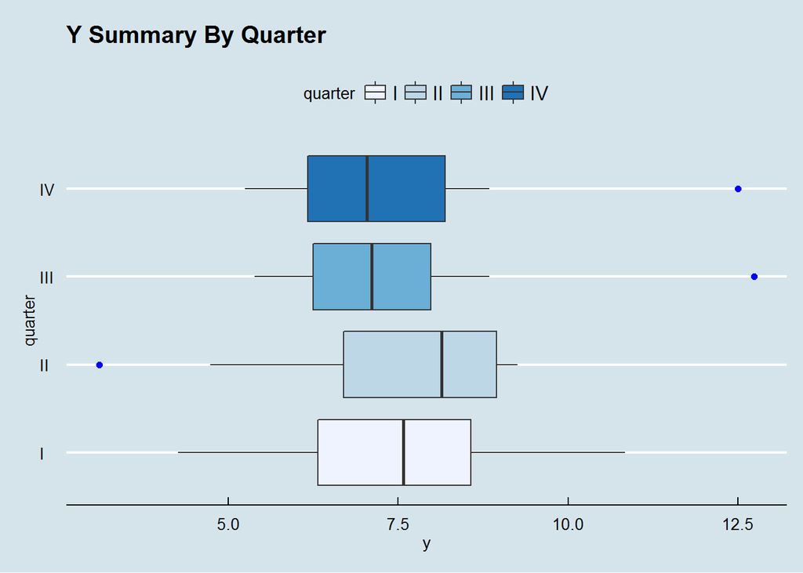

```r
p <- ggplot(data, aes(quarter,y))
p + geom_boxplot(outlier.colour = "blue",aes(fill = quarter)) +
  coord_flip() + scale_fill_brewer() + ggtitle('Y Summary By Quarter')+
  theme_economist() + scale_colour_economist()
```

We now examine the distribution of Y, first by creating a histogram where color denotes the contribution by each quarter

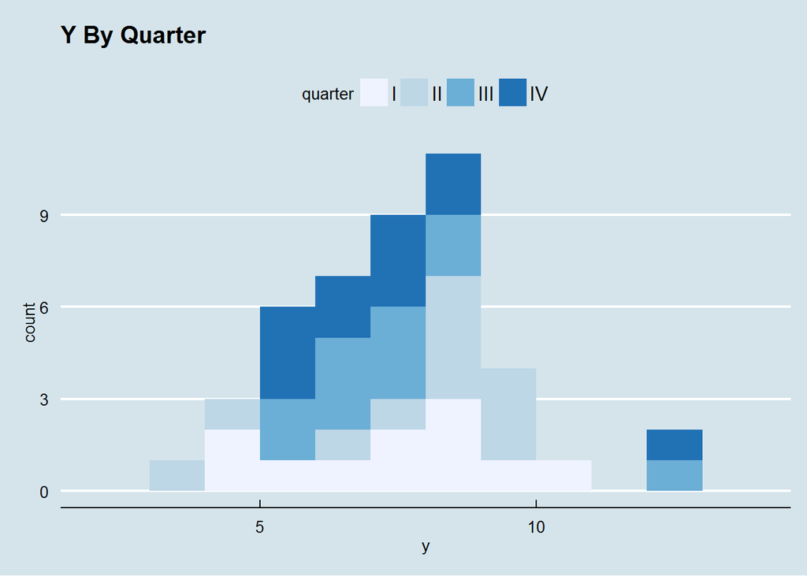

```r
# create a histogram where color denotes contribution by
# each quarter
dplot <- ggplot(data, aes(y, fill = quarter))
dplot + geom_bar(position = "stack",binwidth=1) +
  theme_economist() + scale_colour_economist() +
  scale_fill_brewer() + ggtitle('Y By Quarter')
```

We continue to examine the distribution of Y, focusing next on kernel smoothed densities for each respective quarter.

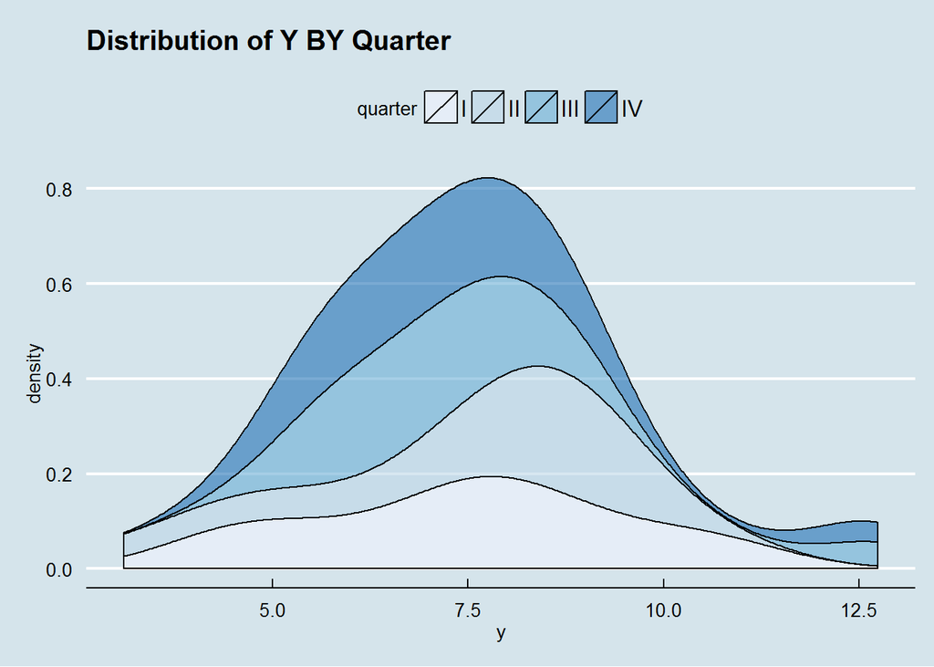

```r
# plot the kernal smoothed density by quarter
qplot(y, data=data, geom="density",position="stack", fill=quarter,
      alpha=I(.6), main="Distribution of Y BY Quarter",
      xlab="y", ylab="density") + scale_fill_brewer() +
  theme_economist() + scale_colour_economist()
```

The shape of the distribution of Y for each quarter is more clear once we look at the distribution for each quarter separately.

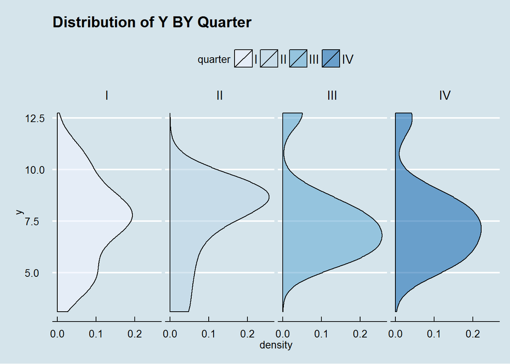

```r
# plot the kernal smoothed density by quarter
qplot(y, data=data, geom="density",position="stack", fill=quarter,
      alpha=I(.6), main="Distribution of Y BY Quarter",
      xlab="y", ylab="density") + scale_fill_brewer() +
  theme_economist() + scale_colour_economist() +
  facet_grid(. ~ quarter) +  coord_flip()
```

The density differs significantly by quarter. The mode of the distribution shifts.